# R Notebook

3. Creation of a union peak list/set with DiffBind:
1. Peak filtering
2. Sample filtering: Some samples have very low peaks.
3. union list https://bioconductor.org/packages/release/bioc/html/DiffBind.html

Currently, peaks are called for each sample individually. Next, you need to determine which peaks are “valid”, e.g. a peak that was called in at least 10% of the samples is valid. Note: VALID peaks should first be assessed separately for DEX and VEHICLE conditions and for the analysis the union of these lists should be used.

4. Differential analysis. Usually, in ChIPseq you have an input or IgG control and you would use special tools for the differential analysis. This design is different and differential analysis can be carried out very similar to the corresponding RNAseq data analysis in DEseq or edgeR for treatment condition (veh vs. dex). You can also run differential analysis in DiffBind (which calls DeSeq)
5. Allele-specific binding: generate allele-specific count matrix and perform RasQUAL (R-package)

Obtaining the sites significantly differentially bound (DB) between the dex samples and veh samples can be done in a five-step script:

> data = dba(sampleSheet=“samplesheeet.csv”) data = dba.count(data) data = dba.contrast(data, categories=DBA_TREATMENT) data = dba.analyze(data) data.DB = dba.report(data)
1. Read in sampleSheet

```r
head(samples, 5)
```

|  | SampleID | Tissue | Factor | Condition | Treatment | Replicate | bamReads | Peaks | PeakCaller | PeakFormat |
| --- | --- | --- | --- | --- | --- | --- | --- | --- | --- | --- |
| 1 | MPI000637_204526230010_R09C01 | NA | ATAC | low | veh | 1 | /Users/anastasiia_hry/Documents/MPIP/SIgne/08_peaks/07_filter_CNV/mpg_L18015_7C_veh_S26.cutadapt.sorted.filtered.rmDups.noCNV.bam | /Users/anastasiia_hry/Documents/MPIP/SIgne/08_peaks/06_MASC2_callpeak/mpg_L18015_7C_veh_S26_peaks.narrowPeak.filt.gz | macs | narrow |
| 2 | MPI002418_204526230008_R01C02 | NA | ATAC | low | veh | 1 | /Users/anastasiia_hry/Documents/MPIP/SIgne/08_peaks/07_filter_CNV/mpg_L18015_14D_veh_S33.cutadapt.sorted.filtered.rmDups.noCNV.bam | /Users/anastasiia_hry/Documents/MPIP/SIgne/08_peaks/06_MASC2_callpeak/mpg_L18015_14D_veh_S33_peaks.narrowPeak.filt.gz | macs | narrow |
| 3 | MPI003787_204526230010_R04C01 | NA | ATAC | high | dex | 2 | /Users/anastasiia_hry/Documents/MPIP/SIgne/08_peaks/07_filter_CNV/mpg_L18015_15B_dex_S72.cutadapt.sorted.filtered.rmDups.noCNV.bam | /Users/anastasiia_hry/Documents/MPIP/SIgne/08_peaks/06_MASC2_callpeak/mpg_L18015_15B_dex_S72_peaks.narrowPeak.filt.gz | macs | narrow |
| 4 | MPI001701_204526230010_R03C01 | NA | ATAC | high | veh | 1 | /Users/anastasiia_hry/Documents/MPIP/SIgne/08_peaks/07_filter_CNV/mpg_L18015_14B_veh_S60.cutadapt.sorted.filtered.rmDups.noCNV.bam | /Users/anastasiia_hry/Documents/MPIP/SIgne/08_peaks/06_MASC2_callpeak/mpg_L18015_14B_veh_S60_peaks.narrowPeak.filt.gz | macs | narrow |
| 5 | MPI003231_204526230010_R12C01 | NA | ATAC | high | veh | 1 | /Users/anastasiia_hry/Documents/MPIP/SIgne/08_peaks/07_filter_CNV/mpg_L18015_18D_veh_S62.cutadapt.sorted.filtered.rmDups.noCNV.bam | /Users/anastasiia_hry/Documents/MPIP/SIgne/08_peaks/06_MASC2_callpeak/mpg_L18015_18D_veh_S62_peaks.narrowPeak.filt.gz | macs | narrow |

2. Create and save a DBA object

```
95 Samples, 24124 sites in matrix (44967 total):
```

|  | ID | Factor | Condition | Treatment | Replicate | Intervals |
| --- | --- | --- | --- | --- | --- | --- |
| 1 | MPI000637_204526230010_R09C01 | ATAC | low | veh | 1 | 460 |
| 2 | MPI002418_204526230008_R01C02 | ATAC | low | veh | 1 | 354 |
| 3 | MPI003787_204526230010_R04C01 | ATAC | high | dex | 2 | 1955 |
| 4 | MPI001701_204526230010_R03C01 | ATAC | high | veh | 1 | 9725 |
| 5 | MPI003231_204526230010_R12C01 | ATAC | high | veh | 1 | 236 |
| 6 | MPI004171_204526230008_R03C02 | ATAC | low | dex | 2 | 2699 |
| 7 | MPI002604_204526230008_R09C02 | ATAC | low | dex | 2 | 1290 |
| 8 | MPI004054_204526230010_R06C02 | ATAC | low | dex | 2 | 2302 |
| 9 | MPI001263_204526230010_R11C01 | ATAC | high | veh | 1 | 413 |
| 10 | MPI001786_204526230008_R11C02 | ATAC | high | veh | 1 | 977 |

[output cut: 85 more lines]

This shows how many peaks are in each peakset, as well as total number of unique peaks after merging overlapping ones (44’967) and the default binding matrix of 95 samples by the 24’124 sites that overlap in at least two of the samples.

3. Peaksets overlap rate

To determine which peaks are “valid”, we perform overlap peaksets analysis for each group (dex and veh) separately.

3.1. Dex group

```r
dba.overlap(dba.db, dba.db$masks$dex, mode=DBA_OLAP_RATE)
```

```
 [1] 37757 21482 16679 13616 11128  9285  7674  6495  5523  4707  4062  3458  3071  2731  2428  2180  1986  1832  1671  1519  1401  1307  1238  1156  1085  1016   932   890   838
[30]   774   719   683   632   577   541   500   459   419   385   343   306   278   242   216   184   139    93
```

47 consensus peaksets were identified for dex group, 37’757 of which is the total number of unique sites, 21’482 - the number of unique sites appearing in at least two peaksets, 16’679 - the number of sites overlapping in at least three peaksets, etc.

```r
dba.overlap(dba.db, dba.db$masks$dex & dba.db$masks$high, mode=DBA_OLAP_RATE)
```

```
 [1] 24355 11496  7477  5285  3870  2981  2350  1946  1644  1408  1241  1112   973   845   747   665   582   496   407   328   263   206   150    99
```

3.2. Veh group

```r
dba.overlap(dba.db, dba.db$masks$veh, mode=DBA_OLAP_RATE)
```

```
 [1] 21486  8772  5760  4118  3039  2287  1716  1346  1047   832   703   576   478   426   386   336   307   281   251   224   208   188   180   175   163   153   143   139   131
[30]   127   124   120   114   111   107   101    98    97    93    90    87    80    77    75    72    67    62    53
```

```r
dba.overlap(dba.db, dba.db$masks$veh & dba.db$masks$high, mode=DBA_OLAP_RATE)
```

```
 [1] 17310  6567  3583  2090  1219   751   531   397   317   262   212   178   157   141   134   121   111   104    96    87    82    77    68    55
```

4. Create separate consensus peaksets for each of the two treatments (veh and dex), then take the union of these two peaksets as the overall consensus

```r
dba.consensus
```

```
97 Samples, 24124 sites in matrix (44967 total):
```

|  | ID | Factor | Condition | Treatment | Replicate | Intervals |
| --- | --- | --- | --- | --- | --- | --- |
| 1 | MPI000637_204526230010_R09C01 | ATAC | low | veh | 1 | 460 |
| 2 | MPI002418_204526230008_R01C02 | ATAC | low | veh | 1 | 354 |
| 3 | MPI003787_204526230010_R04C01 | ATAC | high | dex | 2 | 1955 |
| 4 | MPI001701_204526230010_R03C01 | ATAC | high | veh | 1 | 9725 |
| 5 | MPI003231_204526230010_R12C01 | ATAC | high | veh | 1 | 236 |
| 6 | MPI004171_204526230008_R03C02 | ATAC | low | dex | 2 | 2699 |
| 7 | MPI002604_204526230008_R09C02 | ATAC | low | dex | 2 | 1290 |
| 8 | MPI004054_204526230010_R06C02 | ATAC | low | dex | 2 | 2302 |
| 9 | MPI001263_204526230010_R11C01 | ATAC | high | veh | 1 | 413 |
| 10 | MPI001786_204526230008_R11C02 | ATAC | high | veh | 1 | 977 |

[output cut: 87 more lines]

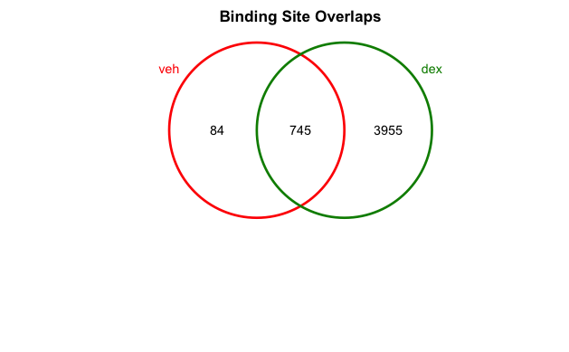

5. Merge peakset list

When forming the global binding matrix consensus peaksets, DiffBind first identifies all unique peaks amongst the relevant peaksets. As part of this process, it merges overlapping peaks, replacing them with a single peak representing the narrowest region that covers all peaks that overlap by at least one base.

Add a consensus peakset (derived from overlapping peaks in peaksets already present) :

```r
dba.consensus.merge <- dba.peakset(dba.consensus, peaks = dba.consensus$masks$Consensus, minOverlap = 1)
dba.consensus.merge
```

Save union peakset :

```r
n             <- length(dba.consensus.merge$peaks)
union.peakset <- dba.consensus.merge$peaks[[n]][,1:3]

write.table(union.peakset, file = paste0(result.dir.fn, "union_peakset.tsv"), sep = "\t", row.names = F, col.names = F, quote = F)
```

6. Generate a binding affinity matrix based on read count scores :

```r
dba.count.db <- dba.count(dba.db, peaks = union.peakset, bRemoveDuplicates = F)
```

```
Computing summits...
Re-centering peaks...
Reads will be counted as Paired-end.
```

7. Establishing contrast

Next we need to let DiffBind know how we want to group our samples. In our case we will group based on treatment. We also have to set the minMembers parameter to 47 since we have 47 samples in dex and 48 in veh group.

8. Differential analysis :

8.1. Normalization

A windowing approach that identifies deferentially enriched regions (from csaw package)

```r
dba.dif.anal.norm <- dba.analyze(dba.contrast.norm, method = DBA_ALL_METHODS)
```

```
Applying Blacklist/Greylists...
Genome detected: Hsapiens.NCBI.GRCh38
Applying blacklist...
Removed: 3 of 4784 intervals.
No control reads specified, unable to generate greylist.
Re-normalizing...
Removed 3 (of 4784) consensus peaks.
Forming default model design and contrast(s)...
Computing results names...
Analyzing...
Repeated column names found in count matrix
```

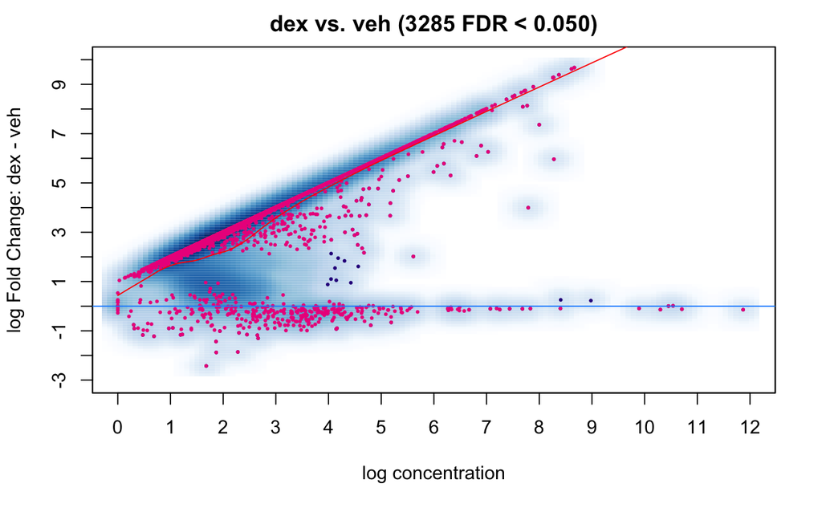

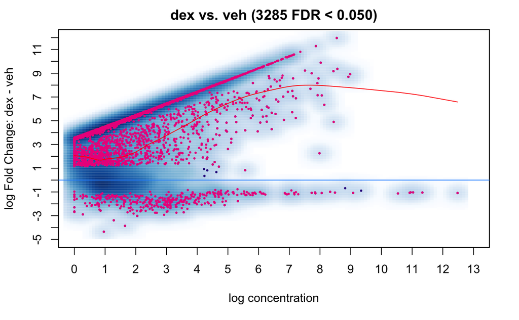

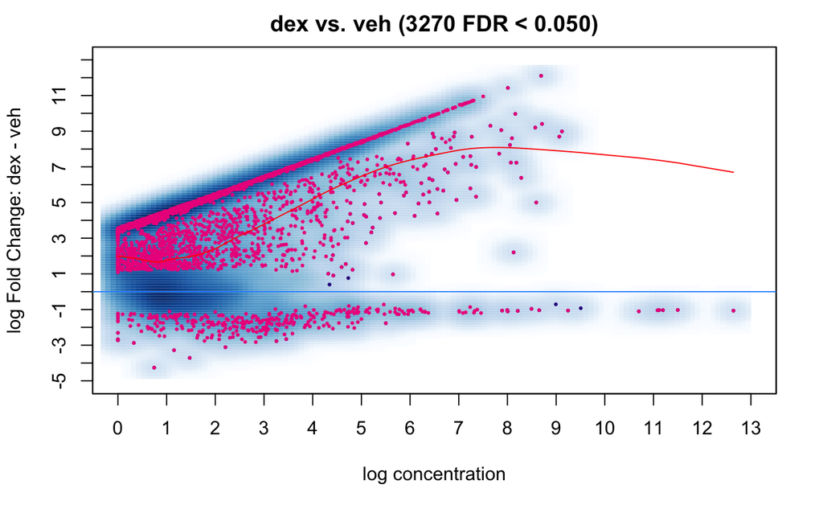

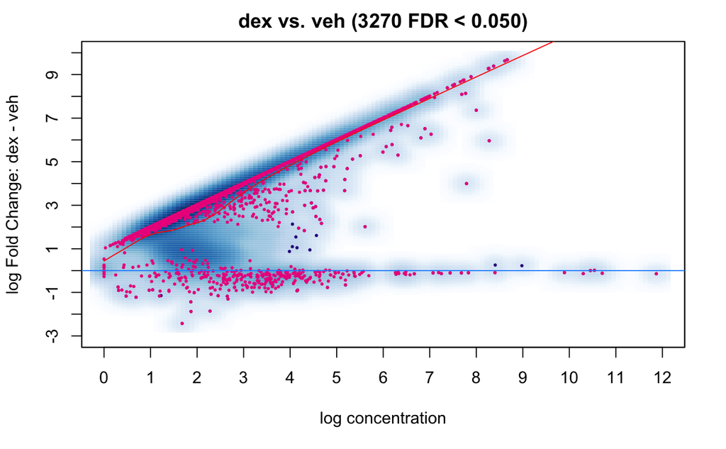

9. Retrieve the dif bound sites

```r
dex.report <- dba.report(dba.dif.anal, contrast = 2, method = DBA_EDGER)
dex.report
```

[output not shown]

- “Conc” shows the mean read concentration over all the samples (the default calculation uses log2 normalized read counts)
- “Conc_dex” - the mean concentration over the samples in dex group
- “Conc_veh” - the mean concentration over the samples in veh group.
- “Fold” - the log fold changes (LFCs) between the two groups. A positive value indicates increased binding affinity in the DEX group, and a negative value indicates increased binding affinity in the VEH group.

The number of differentially bound sites that have enriched in DEX samples :

```r
sum(dex.report$Fold>0)
```

[output not shown]

10. Quantification for edgeR

```r
counts.edger <- dba.dif.anal$edgeR$DEdata$counts
```

11. Peaks annotation

```r
#  This is the refeernce anno used: /ngs/references/human/GRCh38/Homo_sapiens.GRCh38.97.gtf
ref.annot.fn <- paste(wd, "Homo_sapiens.GRCh38.97.gtf", sep = "/")

txDb <- makeTxDbFromGFF(ref.annot.fn, format = "gtf",
                           organism = "Homo sapiens",
                           chrominfo = NULL,
                           dbxrefTag = "gene_id")
# annotate all peaks
dex.anno.report <- ChIPseeker::annotatePeak(dex.report, tssRegion=c(-3000, 150), TxDb=txDb, level = "transcript", overlap = "all" )
dex.anno.report
```

12. Plotting

12.1 PCA

```r
dba.plotPCA(dba.dif.anal, method = DBA_EDGER, attributes = DBA_CONDITION, label = DBA_TREATMENT, contrast = 2)
```

[output not shown]

12.2. Volcano

```r
dba.plotVolcano(dba.dif.anal, method = DBA_EDGER, contrast = 2)
```

[output not shown]

12.3. Boxplot

```r
dba.plotBox(dba.dif.anal, method = DBA_EDGER, contrast = 2)
```

[output not shown]

13. Export results

```r
out.edger <- as.data.frame(dex.report)
write.table(out.edger, file = paste0(result.dir.fn, "dex_edge_report.txt"), sep = "\t", quote = F, row.names = F)
```

Write BED files for each set of significant regions identified by edgeR, separating them based on the gain or loss of enrichment.

```r
dex.enrich <- out.edger %>%
                filter(FDR < 0.05 & Fold > 0) %>%
                select(seqnames, start, end)

write.table(dex.enrich, file = paste0(result.dir.fn, "dex_enriched.bed"), sep = "\t", quote = F, row.names = F, col.names = F)

veh.enrich <- out.edger %>%
                filter(FDR < 0.05 & Fold < 0) %>%
                select(seqnames, start, end)

write.table(veh.enrich, file = paste0(result.dir.fn, "veh_enriched.bed"), sep = "\t", quote = F, row.names = F, col.names = F)
```